# SciPy

## Overview

## Overview

- SciPy builds on top of NumPy to provide common tools for scientific programming, such as
  - linear algebra
  - numerical integration
  - interpolation
  - optimization
  - distributions and random number generation
  - signal processing, etc., etc
- Like NumPy, SciPy is stable, mature and widely used
- Many SciPy routines are thin wrappers around industry-standard Fortran libraries such as LAPACK, BLAS, etc.

## Overview

- It's not really necessary to alearna SciPy as a whole-a better approach is to learn each relevant feature as required
- You can browse from the top of the documentation tree to see what's available
- In this lecture we aim only to highlight some useful parts of the package

## SciPy versus NumPy

## SciPy versus NumPy

- SciPy is a package that contains various tools that are built on top of NumPy, using its array data type and related functionality
- In fact, when we import SciPy we also get NumPy, as can be seen from the SciPy initialization file

```python
# Import numpy symbols to scipy name space
from numpy import *
from numpy.random import rand, randn
from numpy.fft import fft, ifft
from numpy.lib.scimath import *
# Remove the linalg imported from numpy so that the scipy.linalg package can be
# imported.
del linalg
```

- The majority of SciPy's functionality resides in its subpackages
  - `scipy.optimize`, `scipy.integrate`, `scipy.stats`, etc.

## SciPy versus NumPy

- Note that these subpackages need to be imported separately

```python
import scipy.optimize
from scipy.integrate import quad
```

- Although SciPy imports NumPy, the standard approach is to start scientific programs with `import numpy as np`, and then import bits and pieces from SciPy as needed

```python
from scipy.integrate import quad
from scipy.optimize import brentq
# etc
```

- This approach helps clarify what functionality belongs to what package, and we will follow it in these lectures

## Statistics

## Statistics

- The scipy.stats subpackage supplies
  - numerous random variable objects (densities, cumulative distributions, random sampling, etc.)
  - some estimation procedures
  - some statistical tests

## Random Variables and Distributions

- Recall that numpy.random provides functions for generating random variables

```python
import numpy as np
np.random.beta(5, 5, size=3)
```

- This generates a draw from the distribution below when `a, b = 5, 5` \[ f(x;a,b)=\frac{x^{(a-1)}(1-x)^{(b-1)}}{\int^1_0 u^{(a-1)}u^{(b-1)}du}\:(0\leq x\leq 1) \]
- Sometimes we need access to the density itself, or the cdf, the quantiles, etc.
- For this we can use `scipy.stats`, which provides all of this functionality as well as random number generation in a single consistent interface

## Random Variables and Distributions

```python
import numpy as np
from scipy.stats import beta
from matplotlib.pyplot import hist, plot, show
q = beta(5, 5)      # Beta(a, b), with a = b = 5
obs = q.rvs(2000)   # 2000 observations
hist(obs, bins=40, normed=True)
grid = np.linspace(0.01, 0.99, 100)
plot(grid, q.pdf(grid), 'k-', linewidth=2)
show()
```

[output not shown]

- In this code we created a so-called `rv_frozen` object, via the call `q = beta(5, 5)`
- The afrozena part of the notation related to the fact that q represents a particular distribution with a particular set of parameters
- Once we've done so, we can then generate random numbers, evaluate the density, etc., all from this fixed distribution

## Random Variables and Distributions

```python
q.cdf(0.4)      # Cumulative distribution function

q.pdf(0.4)      # Density function

q.ppf(0.8)      # Quantile (inverse cdf) function

q.mean()
```

- The general syntax for creating these objects is `identifier = scipy.stats.distribution_name(shape_parameters)`, where `distribution_name` is one of the distribution names in `scipy.stats`
- There are also two keyword arguments, loc and scale:

```python
identifier = scipy.stats.distribution_name(shape_parameters, `loc=c`, `scale=d`)
```

- These transform the original random variable \(X\) into \(Y=c+dX\)

## Random Variables and Distributions

- The methods `rvs`, `pdf`, `cdf`, etc. are transformed accordingly
- Before finishing this section, we note that there is an alternative way of calling the methods described above

```python
import numpy as np
from scipy.stats import beta
from matplotlib.pyplot import hist, plot, show
obs = beta.rvs(5, 5, size=2000)   # 2000 observations
hist(obs, bins=40, normed=True)
grid = np.linspace(0.01, 0.99, 100)
plot(grid, beta.pdf(grid, 5, 5), 'k-', linewidth=2)
show()
```

## Other Goodies in scipy.stats

- There are also many statistical functions in `scipy.stats`
- For example, `scipy.stats.linregress` implements simple linear regression

```python
from scipy.stats import linregress
x = np.random.randn(200)
y = 2 * x + 0.1 * np.random.randn(200)
gradient, intercept, r_value, p_value, std_err = linregress(x, y)
gradient, intercept
```

- To see the full list of statistical functions, consult the documentation

## Roots and Fixed Points

## Roots and Fixed Points

- A *root* of a real function \(f\) on \([a,b]\) is an \(x\in[a,b]\) such that \(f(x)=0\)
- For example, if we plot the function \[ f(x)=sin(4(x-1/4))+x+x^{20}-1 \] with \(x\in[0,1]\) we get

## Roots and Fixed Points

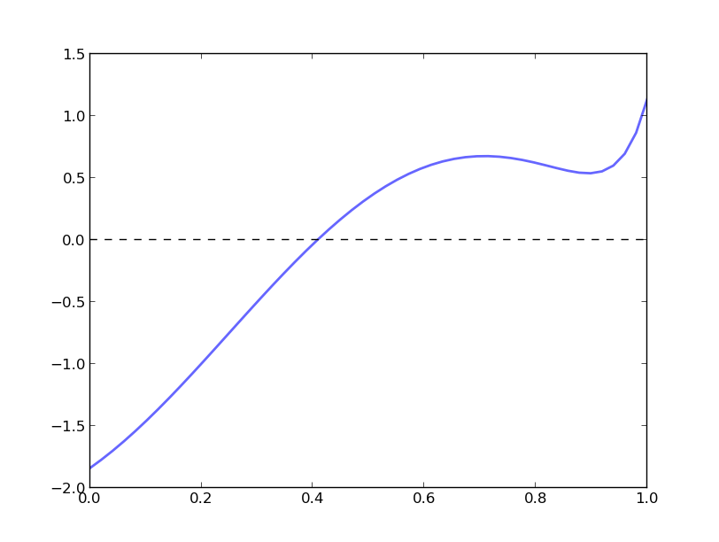

## Roots and Fixed Points

- The unique root is approximately 0.408
- Let's consider some numerical techniques for finding roots

## Bisection

- One of the most common algorithms for numerical root finding is `bisection`
- To understand the idea, recall the well known game where
  - Player A thinks of a secret number between 1 and 100
  - Player B asks if it's less than 50
    - If yes, B asks if it's less than 25
    - If no, B asks if it's less than 75
  - And so on
- This is bisection
- Here's a fairly simplistic implementation of the algorithm in Python
- It works for all sufficiently well behaved increasing continuous functions with \(f(a)<0<f(b)\)

## Bisection

```python
def bisect(f, a, b, tol=10e-5):
    """
    Implements the bisection root finding algorithm, assuming that f is a
    real-valued function on [a, b] satisfying f(a) < 0 < f(b).
    """
    lower, upper = a, b
    while upper - lower > tol:
        middle = 0.5 * (upper + lower)
        # === if root is between lower and middle === #
        if f(middle) > 0:
            lower, upper = lower, middle
        # === if root is between middle and upper  === #
        else:
            lower, upper = middle, upper
    return 0.5 * (upper + lower)
```

## Bisection

- In fact SciPy provides it's own bisection function

```python
from scipy.optimize import bisect
f = lambda x: np.sin(4 * (x - 0.25)) + x + x**20 - 1
bisect(f, 0, 1)
```

## The Newton-Raphson Method

- Another very common root-finding algorithm is the [Newton-Raphson method](https://en.wikipedia.org/wiki/Newton's_method)
- In SciPy this algorithm is implemented by `scipy.newton`
- Unlike bisection, the Newton-Raphson method uses local slope information
- This is a double-edged sword:
  - When the function is well-behaved, the Newton-Raphson method is faster than bisection
  - When the function is less well-behaved, the Newton-Raphson might fail
- Let's investigate this using the same function \(f\), first looking at potential instability

## The Newton-Raphson Method

```python
from scipy.optimize import newton
newton(f, 0.2)   # Start the search at initial condition x = 0.2

newton(f, 0.7)   # Start the search at x = 0.7 instead
```

[output not shown]

```python
timeit bisect(f, 0, 1)

timeit newton(f, 0.2)
```

[output not shown]

## Hybrid Methods

- So far we have seen that the Newton-Raphson method is fast but not robust
- This bisection algorithm is robust but relatively slow
- This illustrates a general principle
  - If you have specific knowledge about your function, you might be able to exploit it to generate efficiency
  - If not, then algorithm choice involves a trade-off between speed of convergence and robustness
- In practice, most default algorithms for root finding, optimization and fixed points use *hybrid* methods

## Hybrid Methods

- These methods typically combine a fast method with a robust method in the following manner:
  - Attempt to use a fast method
  - Check diagnostics
  - If diagnostics are bad, then switch to a more robust algorithm
- In `scipy.optimize`, the function `brentq` is such a hybrid method, and a good default

```python
from scipy.optimize import brentq
brentq(f, 0, 1)

timeit brentq(f, 0, 1)
```

## Multivariate Root Finding

- Use `scipy.optimize.fsolve`, a wrapper for a hybrid method in MINPACK
- See the documentation for details

## Fixed Points

- SciPy has a function for finding (scalar) fixed points too

```python
from scipy.optimize import fixed_point
fixed_point(lambda x: x**2, 10.0)  # 10.0 is an initial guess
```

- If you don't get good results, you can always switch back to the `brentq` root finder, since the fixed point of a function \(f\) is the root of \(g(x):=x-f(x)\)

## Optimization

## Optimization

- Most numerical packages provide only functions for minimization
- Maximization can be performed by recalling that the maximizer of a function \(f\) on domain \(D\) is the minimizer of \(-f\) on \(D\)
- Minimization is closely related to root finding: For smooth functions, interior optima correspond to roots of the first derivative
- The speed/robustness trade-off described above is present with numerical optimization too
- Unless you have some prior information you can exploit, it's usually best to use hybrid methods

## Optimization

- For constrained, univariate (i.e., scalar) minimization, a good hybrid option is `fminbound`

```python
from scipy.optimize import fminbound
fminbound(lambda x: x**2, -1, 2)  # Search in [-1, 2]
```

## Multivariate Optimization

- Multivariate local optimizers include `minimize`, `fmin`, `fmin_powell`, `fmin_cg`, `fmin_bfgs`, and `fmin_ncg`
- Constrained multivariate local optimizers include `fmin_l_bfgs_b`, `fmin_tnc`, `fmin_cobyla`

## Integration

## Integration

- Most numerical integration methods work by computing the integral of an approximating polynomial
- The resulting error depends on how well the polynomial fits the integrand, which in turn depends on how aregulara the integrand is
- In SciPy, the relevant module for numerical integration is `scipy.integrate`
- A good default for univariate integration is `quad`

```python
from scipy.integrate import quad
integral, error = quad(lambda x: x**2, 0, 1)
integral
```

## Integration

- In fact `quad` is an interface to a very standard numerical integration routine in the Fortran library QUADPACK
- It uses [Clenshaw-Curtis quadrature](https://en.wikipedia.org/wiki/Clenshaw%E2%80%93Curtis_quadrature), based on expansion in terms of Chebychev polynomials
- There are other options for univeriate integration-a useful one is `fixed_quad`, which is fast and hence works well inside for loops
- There are also functions for multivariate integration. See the documentation for more details

## Linear Algebra

## Linear Algebra

- We saw that NumPy provides a module for linear algebra called `linalg`
- SciPy also provides a module for linear algebra with the same name
- The latter is not an exact superset of the former, but overall it has more functionality
- We leave you to investigate the set of available routines

## Exercises

## Exercise 1

- Basically, a recursive function is a function that calls itself
- For example, consider the problem of computing \(x_t\) for some t when \[ x_{t+1}=2x_t,x_0=1 \]
- Obviously the answer is \(2^t\)
- We can compute this easily enough with a loop

```python
def x_loop(t):
    x = 1
    for i in range(t):
        x = 2 * x
    return x
```

## Exercise 1

- We can also use a recursive solution, as follows

```python
def x(t):
    if t == 0:
        return 1
    else:
        return 2 * x(t-1)
```

- What happens here is that each successive call uses it's own *frame* in the stack
  - a frame is where the local variables of a given function call are held
  - stack is memory used to process function calls
    - a First In Last Out (FILO) queue

## Exercise 1

- Write a recursive implementation of the bisection function described above, which we repeat here for convenience
- Test it on the function `f = lambda x: np.sin(4 * (x - 0.25)) + x + x**20 - 1` discussed above

## Exercise 1

```python
def bisect(f, a, b, tol=10e-5):
    """
    Implements the bisection root finding algorithm, assuming that f is a
    real-valued function on [a, b] satisfying f(a) < 0 < f(b).
    """
    lower, upper = a, b
    while upper - lower > tol:
        middle = 0.5 * (upper + lower)
        # === if root is between lower and middle === #
        if f(middle) > 0:
            lower, upper = lower, middle
        # === if root is between middle and upper  === #
        else:
            lower, upper = middle, upper
    return 0.5 * (upper + lower)
```